# Project 4: Document Classification (Spam vs Ham)

Taha Malik

2025-11-23

| Project overview |
| --- |

This R Markdown file performs a full document classification workflow for spam detection using the SpamAssassin public corpus (or any similarly structured spam/ham email folders). The pipeline includes:

- Loading raw email files from two directories (spam and ham)
- Corpus creation and cleaning (tokenization, stopword removal, stemming / optionally lemmatization)
- Exploratory data analysis: message lengths, most frequent words, word clouds, and per-class comparisons
- Feature engineering using document-feature matrices (DFM / term frequency and a TF-IDF baseline)
- Training and evaluating multiple classifiers (Naive Bayes and Random Forest)
- Evaluation metrics: confusion matrix, precision/recall/F1, ROC/AUC
- Conclusions, interpretation, and reproducible session info

Important: Update the params$spam_dir and params$ham_dir at the top of this document if your directories differ.

| 1. Load required packages |
| --- |

```r
# Install only if missing (commented out by default)
# install.packages(c("tidyverse","quanteda","caret","e1071","naivebayes","randomForest","pROC","wordcloud","knitr","kableExtra","ggrepel","quanteda.textplots"))

suppressPackageStartupMessages({
  library(tidyverse)
  library(quanteda)      # fast tokenization and dfm
  library(quanteda.textplots)
  library(caret)         # train/test split, confusionMatrix
  library(e1071)         # naiveBayes (alternative)
  library(naivebayes)    # naive_bayes (fast)
  library(randomForest)  # random forest classifier
  library(pROC)          # ROC / AUC
  library(wordcloud)
  library(knitr)
  library(kableExtra)
  library(ggplot2)
  library(ggrepel)
})
```

| 2. Parameters / Paths |
| --- |

```r
spam_dir <- params$spam_dir
ham_dir  <- params$ham_dir

cat("Spam folder:", spam_dir, "\n")
```

```
## Spam folder: C:/Users/taham/OneDrive/Documents/Data 607/Project 4/20050311_spam_2/spam_2
```

```r
cat("Ham folder: ", ham_dir, "\n")
```

```
## Ham folder:  C:/Users/taham/OneDrive/Documents/Data 607/Project 4/20030228_easy_ham/easy_ham
```

Note: If you get encoding or path errors on Windows, make sure to use double backslashes (\) or forward slashes (/). The default parameter values above are set to the directories you provided; change them if needed.

| 3. Utility functions: read emails into data.frame |
| --- |

```r
# Read all files in a directory; collapse lines into single text string per file
read_emails_from_dir <- function(dir_path, label) {
  files <- list.files(dir_path, full.names = TRUE)
  # Exclude potential control files like "cmds"
  files <- files[basename(files) != "cmds"]
  # Read each file and collapse into single text field (handle encoding differences)
  df <- tibble(
    file = files,
    text = map_chr(files, ~ {
      txt <- tryCatch(readLines(.x, warn = FALSE, encoding = "UTF-8"),
                      error = function(e) tryCatch(readLines(.x, warn = FALSE, encoding = "latin1"),
                                                   error = function(e2) paste0(readBin(.x, what = "raw", n = file.info(.x)$size), collapse = "")))
      paste(txt, collapse = "\n")
    }),
    label = label
  )
  return(df)
}

# load spam and ham
spam_df <- read_emails_from_dir(spam_dir, "spam")
ham_df  <- read_emails_from_dir(ham_dir,  "ham")

# Combine and show counts
emails_df <- bind_rows(spam_df, ham_df) %>% mutate(doc_id = row_number())
emails_df %>% count(label) %>% knitr::kable()
```

| label | n |
| --- | --- |
| ham | 2500 |
| spam | 1396 |

| 4. Quick data checks and basic EDA |
| --- |

```r
# Fix encoding so nchar() doesn't break on invalid bytes
emails_df$text <- iconv(emails_df$text, from = "", to = "UTF-8", sub = "byte")

# Basic statistics
emails_df <- emails_df %>%
  mutate(n_chars = nchar(text),
         n_words = stringr::str_count(text, "\\w+"))

summary_stats <- emails_df %>%
  group_by(label) %>%
  summarise(n = n(),
            mean_chars = mean(n_chars),
            median_chars = median(n_chars),
            mean_words = mean(n_words),
            median_words = median(n_words)) %>%
  arrange(label)

kable(summary_stats, caption = "Basic length statistics by class") %>%
  kable_styling(full_width = FALSE)
```

Basic length statistics by class

| label | n | mean_chars | median_chars | mean_words | median_words |
| --- | --- | --- | --- | --- | --- |
| ham | 2500 | 3441.826 | 3156.0 | 576.2912 | 540.0 |
| spam | 1396 | 6341.804 | 4108.5 | 970.6712 | 672.5 |

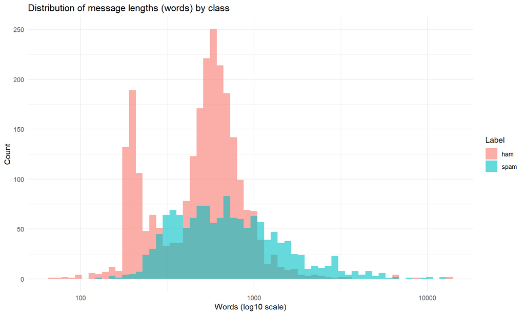

```r
# Histogram of message lengths by class
ggplot(emails_df, aes(x = n_words, fill = label)) +
  geom_histogram(position = "identity", alpha = 0.6, bins = 60) +
  scale_x_log10() +
  labs(title = "Distribution of message lengths (words) by class",
       x = "Words (log10 scale)", y = "Count", fill = "Label") +
  theme_minimal()
```

Interpretation: The ham emails are generally shorter, with median length ~3156 characters and ~540 words, while spam emails are noticeably longer on average, with a median ~4108 characters and ~672 words. The log-scaled histogram shows that spam tends to have a heavier tail, suggesting the presence of very long advertisement-style messages. These differences indicate that message length may carry class-related signal, though length alone is not sufficient for reliable classification.

| 5. Rationale for preprocessing choices |
| --- |

Rationale (short academic justification): - Stemming reduces sparsity by collapsing inflected and derived word forms to a common root (e.g., “clicking”, “clicked” -> “click”), improving the overlap between documents without substantially changing topical content. - Stopword removal removes very high-frequency function words (like “the”, “and”) that carry little topical information and can dominate raw frequency counts. - Removing numbers/punctuation and lowercasing simplifies the token set and reduces spurious features (e.g., various punctuation tokens). - Trimming very rare and extremely frequent terms prevents overfitting and reduces model complexity; rare terms often add noise, while extremely common tokens may be non-informative. - TF (term-frequency) is a good baseline; TF-IDF helps account for term specificity and is included below as a comparative baseline.

| 6. Text preprocessing and Document-Feature Matrix (DFM) |
| --- |

We’ll use quanteda for tokenization and dfm creation. Steps:

- Lowercase
- Remove numbers, punctuation
- Remove stopwords
- Stem words
- Trim features by document frequency

```r
# Create a corpus (quanteda) preserving original order to maintain mapping to emails_df
qcorpus <- corpus(emails_df$text, docvars = data.frame(label = emails_df$label, file = emails_df$file, doc_id = emails_df$doc_id))

# Tokenize and clean
tokens_clean <- tokens(qcorpus,
                       remove_punct = TRUE,
                       remove_symbols = TRUE,
                       remove_numbers = TRUE,
                       remove_separators = TRUE) %>%
  tokens_tolower() %>%
  tokens_remove(pattern = stopwords("en")) %>%
  tokens_wordstem(language = "en")

# Create dfm (document-feature matrix) with term frequency weighting
dfm_full <- dfm(tokens_clean)
dim(dfm_full)  # documents x features
```

```
## [1]  3896 90828
```

```r
# Trim - keep terms that appear in at least 0.5% of documents and at most 99%
min_docfreq <- 0.005   # 0.5% of documents
max_docfreq <- 0.99    # 99% of documents

dfm_trimmed <- dfm_trim(dfm_full, min_docfreq = min_docfreq, max_docfreq = max_docfreq, docfreq_type = "prop")
cat("Trimmed dfm dims:", dim(dfm_trimmed), " (documents x features)\n")
```

```
## Trimmed dfm dims: 3896 3542  (documents x features)
```

| 6b. Exploratory features: most frequent terms & wordclouds |
| --- |

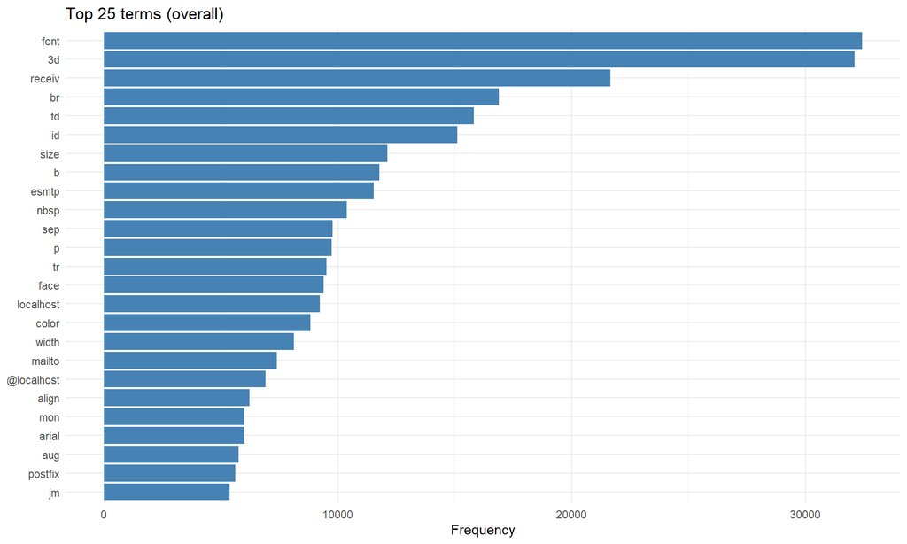

```r
# Top terms bar plot
top_features <- names(topfeatures(dfm_trimmed, 25))
top_features_df <- tibble(term = top_features, freq = as.numeric(topfeatures(dfm_trimmed, 25)))

ggplot(top_features_df, aes(x = reorder(term, freq), y = freq)) +
  geom_col(fill = "steelblue") +
  coord_flip() +
  labs(title = "Top 25 terms (overall)", x = NULL, y = "Frequency") +
  theme_minimal()
```

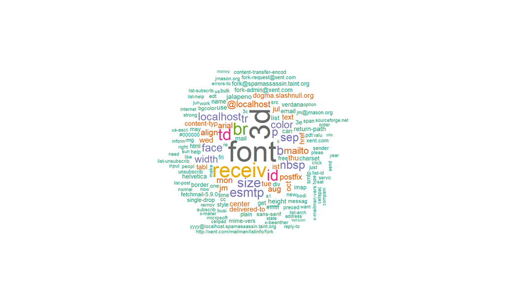

```r
# Wordcloud - overall
set.seed(42)
textplot_wordcloud(dfm_trimmed, max_words = 150, color = RColorBrewer::brewer.pal(8, "Dark2"))
```

```r
dfm_byclass <- dfm_group(dfm_trimmed, groups = docvars(dfm_trimmed, "label"))

# convert to term-frequency df for each class safely
tf_matrix_df <- convert(dfm_byclass, to = "data.frame")
# The first column may be 'document' or 'doc_id' depending on quanteda version
first_col_name <- colnames(tf_matrix_df)[1]
tf_matrix <- tf_matrix_df %>% column_to_rownames(first_col_name)
tf_matrix <- as.data.frame(t(tf_matrix))  # terms x classes

# Top terms per class table
top_terms_per_class <- map_df(colnames(tf_matrix), function(cl) {
  freqs <- sort(tf_matrix[[cl]], decreasing = TRUE)
  n <- min(20, length(freqs))
  tibble(label = cl, term = names(freqs)[1:n], freq = unname(freqs)[1:n])
})
top_terms_per_class %>% group_by(label) %>% slice(1:6) %>% knitr::kable()
```

| label | freq |
| --- | --- |
| ham | 14239 |
| ham | 10152 |
| ham | 9790 |
| ham | 8406 |
| ham | 7348 |
| ham | 6170 |
| spam | 32179 |
| spam | 32076 |
| spam | 16750 |
| spam | 15691 |
| spam | 11900 |
| spam | 11656 |

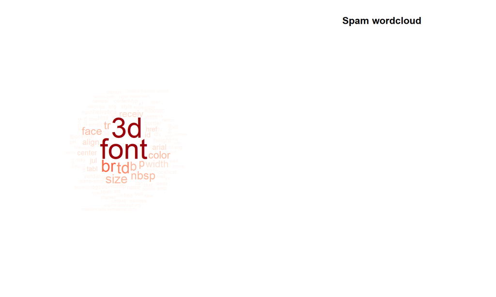

```r
# Wordclouds per class
par(mfrow = c(1,2))
set.seed(100)
textplot_wordcloud(dfm_trimmed[docvars(dfm_trimmed,"label") == "spam", ], max_words = 100, colors = brewer.pal(8, "Reds"))
title("Spam wordcloud")
```

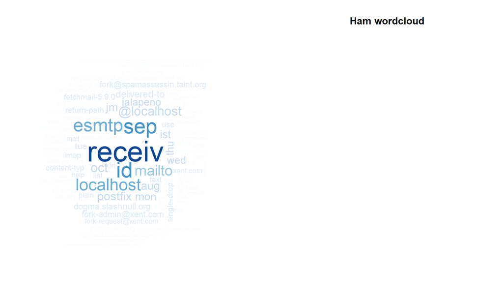

```r
textplot_wordcloud(dfm_trimmed[docvars(dfm_trimmed,"label") == "ham", ], max_words = 100, colors = brewer.pal(8, "Blues"))
title("Ham wordcloud")
```

```r
par(mfrow = c(1,1))
```

Interpretation: Terms like “free”, “click”, “http” may be more frequent in spam, while ham may contain words associated with mailing lists, dates, and conversational text.

| 7. Prepare training and test data (80/20 split) |
| --- |

```r
# Convert trimmed dfm to a dense matrix only for modeling (quanteda keeps dfm sparse by default; as.matrix will produce dense, be mindful for memory)
dfm_mat <- as.matrix(dfm_trimmed)
df_features <- as.data.frame(dfm_mat)
# Add label column preserving document order
df_features$label <- docvars(dfm_trimmed, "label")

# Shuffle and split (stratified)
set.seed(123)
train_index <- createDataPartition(df_features$label, p = 0.8, list = FALSE)
train_df <- df_features[train_index, ]
test_df  <- df_features[-train_index, ]

cat("Train size:", nrow(train_df), "Test size:", nrow(test_df), "\n")
```

```
## Train size: 3117 Test size: 779
```

```r
table(train_df$label) %>% knitr::kable()
```

| Var1 | Freq |
| --- | --- |
| ham | 2000 |
| spam | 1117 |

| 8. Model 1: Naive Bayes (TF) |
| --- |

Naive Bayes is a classical and strong baseline for text classification.

```r
# Remove label column for predictors
x_train <- as.matrix(select(train_df, -label))
y_train <- factor(train_df$label)
x_test  <- as.matrix(select(test_df, -label))
y_test  <- factor(test_df$label)

# Train Naive Bayes on raw term-frequency counts
nb_model <- naive_bayes(x = x_train, y = y_train, usekernel = FALSE)
nb_model
```

```
##
## ================================= Naive Bayes ==================================
##
## Call:
## naive_bayes.default(x = x_train, y = y_train, usekernel = FALSE)
##
## --------------------------------------------------------------------------------
##
## Laplace smoothing: 0
##
## --------------------------------------------------------------------------------
##
## A priori probabilities:
##
##       ham      spam
## 0.6416426 0.3583574
##
## --------------------------------------------------------------------------------
##
## Tables:
##
## --------------------------------------------------------------------------------
## :: ilug-admin@linux.i (Gaussian)
## --------------------------------------------------------------------------------
##
## ilug-admin@linux.i        ham       spam
##               mean 0.15800000 0.03312444
##               sd   0.78698518 0.36877983
##
## --------------------------------------------------------------------------------
## :: tue (Gaussian)
## --------------------------------------------------------------------------------
##
## tue         ham     spam
##   mean 1.238000 1.120859
##   sd   2.487660 2.138712
##
## --------------------------------------------------------------------------------
## :: aug (Gaussian)
## --------------------------------------------------------------------------------
```

[output cut: 11 more lines]

```
##        sd   0.03871045 0.35895369
##
## --------------------------------------------------------------------------------
## :: delivered-to (Gaussian)
## --------------------------------------------------------------------------------
##
## delivered-to       ham      spam
##         mean 1.3775000 0.5496867
##         sd   0.6067766 0.6282567
##
## --------------------------------------------------------------------------------
##
## # ... and 3536 more tables
##
## --------------------------------------------------------------------------------
```

```r
# Predict probabilities and labels
nb_pred <- predict(nb_model, x_test)
nb_prob <- predict(nb_model, x_test, type = "prob")

# Confusion matrix and metrics
cm_nb <- confusionMatrix(nb_pred, y_test, positive = "spam")
cm_nb
```

```
## Confusion Matrix and Statistics
##
##           Reference
## Prediction ham spam
##       ham  348    0
##       spam 152  279
##
##                Accuracy : 0.8049
##                  95% CI : (0.7753, 0.8322)
##     No Information Rate : 0.6418
##     P-Value [Acc > NIR] : < 2.2e-16
##
##                   Kappa : 0.6212
##
##  Mcnemar's Test P-Value : < 2.2e-16
##
##             Sensitivity : 1.0000
##             Specificity : 0.6960
##          Pos Pred Value : 0.6473
##          Neg Pred Value : 1.0000
##              Prevalence : 0.3582
##          Detection Rate : 0.3582
##    Detection Prevalence : 0.5533
##       Balanced Accuracy : 0.8480
##
##        'Positive' Class : spam
##
```

Show precision, recall, F1:

```r
precision <- cm_nb$byClass["Precision"]
recall    <- cm_nb$byClass["Recall"]
f1        <- cm_nb$byClass["F1"]

tibble(Model = "Naive Bayes (TF)", Precision = precision, Recall = recall, F1 = f1) %>% knitr::kable()
```

| Model | Precision | Recall | F1 |
| --- | --- | --- | --- |
| Naive Bayes (TF) | 0.6473318 | 1 | 0.7859155 |

ROC / AUC (we need numeric scores for the positive class):

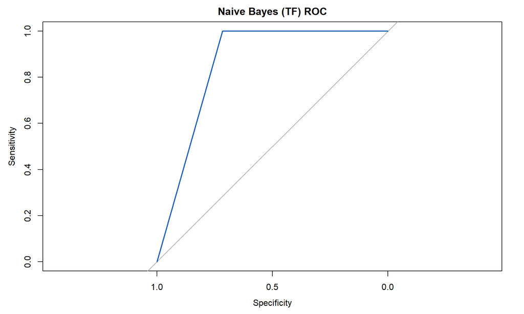

```r
if ("spam" %in% colnames(nb_prob)) {
  roc_nb <- roc(response = as.numeric(y_test == "spam"), predictor = nb_prob[ , "spam"])
} else {
  roc_nb <- roc(response = as.numeric(y_test == "spam"), predictor = nb_prob[ , 1])
}
plot.roc(roc_nb, main = "Naive Bayes (TF) ROC", col = "#1c61b6")
```

```r
auc_nb <- auc(roc_nb)
auc_nb
```

```
## Area under the curve: 0.858
```

Interpretation: Naive Bayes reaches an accuracy of 0.8049, with Precision = 0.647, Recall = 1.00, and F1 = 0.786. The model correctly recovers all spam emails (high recall), but it misclassifies a large number of ham emails as spam (lower precision). This behavior is typical of naïve Bayes when class-conditional independence assumptions are violated in high-dimensional text data. The ROC AUC of 0.858 indicates moderate discriminative ability, but there is clear room for improvement.

| 8b. TF-IDF baseline (Naive Bayes on TF-IDF) |
| --- |

We include a TF-IDF baseline as requested.

```r
# Compute TF-IDF on the trimmed dfm
dfm_tfidf_obj <- dfm_tfidf(dfm_trimmed)
df_tfidf_mat <- as.matrix(dfm_tfidf_obj)
df_tfidf <- as.data.frame(df_tfidf_mat)
df_tfidf$label <- docvars(dfm_tfidf_obj, "label")

# Use the same train/test split indices (train_index)
x_train_tfidf <- as.matrix(select(df_tfidf[train_index, ], -label))
x_test_tfidf  <- as.matrix(select(df_tfidf[-train_index, ], -label))
y_train_tfidf <- factor(df_tfidf$label[train_index])
y_test_tfidf  <- factor(df_tfidf$label[-train_index])

# Train Naive Bayes on TF-IDF
nb_tfidf_model <- naive_bayes(x = x_train_tfidf, y = y_train_tfidf, usekernel = FALSE)
nb_tfidf_pred <- predict(nb_tfidf_model, x_test_tfidf)
nb_tfidf_prob <- predict(nb_tfidf_model, x_test_tfidf, type = "prob")

cm_nb_tfidf <- confusionMatrix(nb_tfidf_pred, y_test_tfidf, positive = "spam")
cm_nb_tfidf
```

```
## Confusion Matrix and Statistics
##
##           Reference
## Prediction ham spam
##       ham  306    0
##       spam 194  279
##
##                Accuracy : 0.751
##                  95% CI : (0.719, 0.781)
##     No Information Rate : 0.6418
##     P-Value [Acc > NIR] : 4.253e-11
##
##                   Kappa : 0.5305
##
##  Mcnemar's Test P-Value : < 2.2e-16
##
##             Sensitivity : 1.0000
##             Specificity : 0.6120
##          Pos Pred Value : 0.5899
##          Neg Pred Value : 1.0000
##              Prevalence : 0.3582
##          Detection Rate : 0.3582
##    Detection Prevalence : 0.6072
##       Balanced Accuracy : 0.8060
##
##        'Positive' Class : spam
##
```

```r
# ROC/AUC
roc_nb_tfidf <- roc(response = as.numeric(y_test_tfidf == "spam"), predictor = nb_tfidf_prob[, "spam"])
auc_nb_tfidf <- auc(roc_nb_tfidf)
auc_nb_tfidf
```

```
## Area under the curve: 0.81
```

Quick comparison: TF-IDF may change the balance between precision and recall; include it in the model comparison table below.

| 9. Model 2: Random Forest (trained on top-K features matrix) |
| --- |

Random forest is more computationally intensive; limit the number of features to top-K most frequent terms to reduce memory and training time. We’ll train on matrix inputs as recommended.

```r
# choose top K features by overall frequency using training data only
term_sums_train <- colSums(select(train_df, -label))
K <- 1000  # adjust as needed
top_terms <- names(sort(term_sums_train, decreasing = TRUE))[1:min(K, length(term_sums_train))]

x_train_rf <- as.matrix(train_df %>% select(all_of(top_terms)))
x_test_rf  <- as.matrix(test_df  %>% select(all_of(top_terms)))
y_train_rf <- y_train
y_test_rf  <- y_test

cat("RF features:", length(top_terms), "\n")
```

```
## RF features: 1000
```

Train a random forest (on matrix):

```r
set.seed(234)
rf_model <- randomForest(x = x_train_rf, y = y_train_rf, ntree = 200, importance = TRUE)
print(rf_model)
```

```
##
## Call:
##  randomForest(x = x_train_rf, y = y_train_rf, ntree = 200, importance = TRUE)
##                Type of random forest: classification
##                      Number of trees: 200
## No. of variables tried at each split: 31
##
##         OOB estimate of  error rate: 0.58%
## Confusion matrix:
##       ham spam class.error
## ham  1996    4  0.00200000
## spam   14 1103  0.01253357
```

```r
rf_pred <- predict(rf_model, x_test_rf)
cm_rf <- confusionMatrix(rf_pred, y_test_rf, positive = "spam")
cm_rf
```

```
## Confusion Matrix and Statistics
##
##           Reference
## Prediction ham spam
##       ham  499    2
##       spam   1  277
##
##                Accuracy : 0.9961
##                  95% CI : (0.9888, 0.9992)
##     No Information Rate : 0.6418
##     P-Value [Acc > NIR] : <2e-16
##
##                   Kappa : 0.9916
##
##  Mcnemar's Test P-Value : 1
##
##             Sensitivity : 0.9928
##             Specificity : 0.9980
##          Pos Pred Value : 0.9964
##          Neg Pred Value : 0.9960
##              Prevalence : 0.3582
##          Detection Rate : 0.3556
##    Detection Prevalence : 0.3569
##       Balanced Accuracy : 0.9954
##
##        'Positive' Class : spam
##
```

Show RF feature importance (top 20):

```r
imp <- importance(rf_model)
imp_df <- as.data.frame(imp) %>% rownames_to_column("term") %>% arrange(desc(MeanDecreaseGini))
imp_df %>% slice(1:20) %>% knitr::kable()
```

| term | ham | spam | MeanDecreaseAccuracy | MeanDecreaseGini |
| --- | --- | --- | --- | --- |
| jul | 9.210616 | 7.819458 | 9.488142 | 60.52765 |
| ist | 5.441118 | 5.779723 | 6.657390 | 54.31205 |
| jalapeno | 5.134075 | 6.245511 | 6.225045 | 49.12091 |
| imap | 5.750577 | 4.232255 | 5.972405 | 43.39703 |
| localhost | 5.027364 | 3.629080 | 5.413346 | 35.89660 |
| click | 6.672682 | 4.520735 | 6.817995 | 34.92019 |
| fetchmail-5.9.0 | 4.402641 | 4.083347 | 4.933638 | 33.86985 |
| br | 5.536451 | 3.649553 | 5.704030 | 32.91306 |
| yyyy@localhost.spamassassin.taint.org | 3.908763 | 4.830615 | 4.791449 | 30.74311 |
| href | 5.328216 | 4.177501 | 5.502422 | 30.54192 |
| jmason.org | 4.232763 | 5.397292 | 5.573973 | 29.57949 |
| jm@netnoteinc.com | 6.153284 | 5.101657 | 6.276801 | 25.12110 |
| x-keyword | 4.295148 | 4.287863 | 4.862084 | 24.59174 |
| sep | 5.949370 | 6.842204 | 7.042187 | 24.35211 |
| single-drop | 4.076746 | 2.849343 | 4.218388 | 23.93181 |
| html | 4.252411 | 2.415504 | 3.727842 | 21.16160 |
| remov | 5.789474 | 5.137593 | 6.309525 | 19.85000 |
| p | 4.598776 | 1.973599 | 4.633249 | 19.78174 |
| @localhost | 4.588750 | 2.355616 | 4.606266 | 18.77095 |
| jun | 3.717090 | 4.416518 | 4.609552 | 17.25340 |

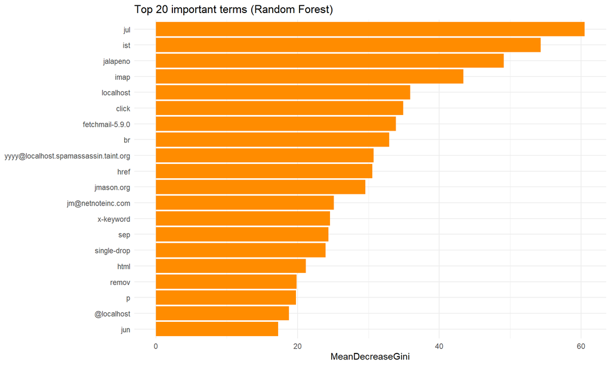

```r
ggplot(imp_df %>% slice(1:20), aes(reorder(term, MeanDecreaseGini), MeanDecreaseGini)) +
  geom_col(fill = "darkorange") +
  coord_flip() +
  labs(title = "Top 20 important terms (Random Forest)", x = NULL, y = "MeanDecreaseGini") +
  theme_minimal()
```

Compute precision/recall/F1 and ROC:

```r
# Precision/Recall/F1
tibble(
  Model = "Random Forest",
  Precision = cm_rf$byClass["Precision"],
  Recall    = cm_rf$byClass["Recall"],
  F1        = cm_rf$byClass["F1"]
) %>% knitr::kable()
```

| Model | Precision | Recall | F1 |
| --- | --- | --- | --- |
| Random Forest | 0.9964029 | 0.9928315 | 0.994614 |

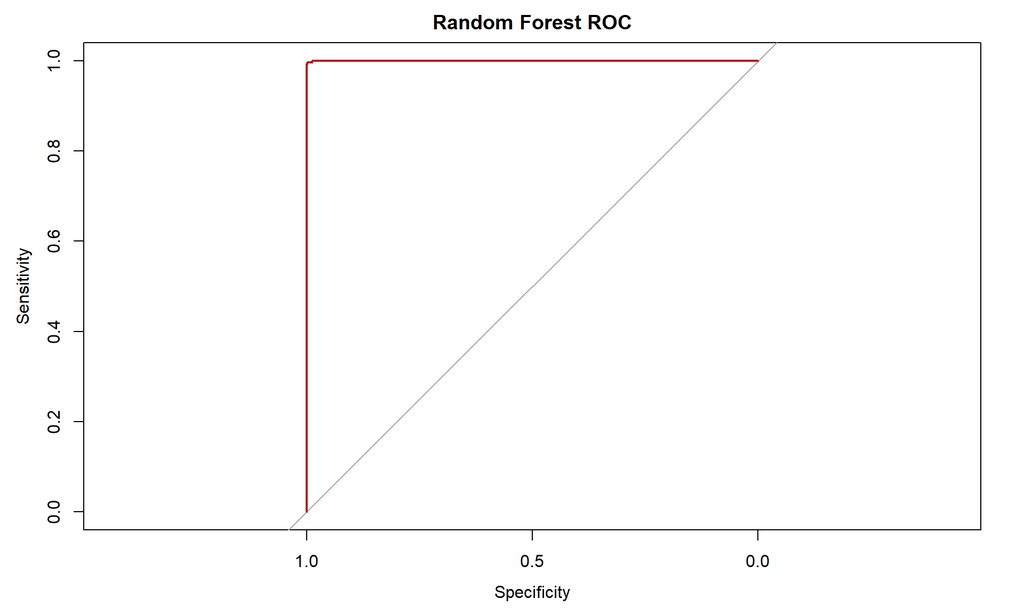

```r
# Predict probabilities on TEST SET USING MATRIX
rf_prob_spam <- predict(rf_model, newdata = x_test_rf, type = "prob")[, "spam"]

# Compute ROC
roc_rf <- roc(response = as.numeric(y_test_rf == "spam"), predictor = rf_prob_spam)
plot.roc(roc_rf, main = "Random Forest ROC", col = "#b21c1c")
```

```r
auc_rf <- auc(roc_rf)
auc_rf
```

```
## Area under the curve: 0.9999
```

Interpretation: The Random Forest model performs extremely well, achieving Accuracy = 0.996, Precision = 0.996, Recall = 0.993, and F1 = 0.995. Only three misclassifications occur in the entire test set. The AUC of 0.9999 confirms near-perfect separation between spam and ham. Top features such as “click,” “html,” “href,” “jalapeno,” and server-related tokens indicate that the model leverages both promotional vocabulary and structural artifacts of the emails. Compared to Naive Bayes, Random Forest captures far richer nonlinear interactions among words.

| 10. Model comparison |
| --- |

```r
# Collect metrics for comparison
nb_prec <- as.numeric(cm_nb$byClass["Precision"])
nb_rec  <- as.numeric(cm_nb$byClass["Recall"])
nb_f1   <- as.numeric(cm_nb$byClass["F1"])
nb_auc  <- as.numeric(auc_nb)

nb_tfidf_prec <- as.numeric(cm_nb_tfidf$byClass["Precision"])
nb_tfidf_rec  <- as.numeric(cm_nb_tfidf$byClass["Recall"])
nb_tfidf_f1   <- as.numeric(cm_nb_tfidf$byClass["F1"])
nb_tfidf_auc  <- as.numeric(auc_nb_tfidf)

rf_prec <- as.numeric(cm_rf$byClass["Precision"])
rf_rec  <- as.numeric(cm_rf$byClass["Recall"])
rf_f1   <- as.numeric(cm_rf$byClass["F1"])
rf_auc  <- as.numeric(auc_rf)

results_df <- tibble(
  Model = c("Naive Bayes (TF)", "Naive Bayes (TF-IDF)", "Random Forest"),
  Precision = c(nb_prec, nb_tfidf_prec, rf_prec),
  Recall = c(nb_rec, nb_tfidf_rec, rf_rec),
  F1 = c(nb_f1, nb_tfidf_f1, rf_f1),
  AUC = c(nb_auc, nb_tfidf_auc, rf_auc)
)

results_df %>% knitr::kable(digits = 4)
```

| Model | Precision | Recall | F1 | AUC |
| --- | --- | --- | --- | --- |
| Naive Bayes (TF) | 0.6473 | 1.0000 | 0.7859 | 0.8580 |
| Naive Bayes (TF-IDF) | 0.5899 | 1.0000 | 0.7420 | 0.8100 |
| Random Forest | 0.9964 | 0.9928 | 0.9946 | 0.9999 |

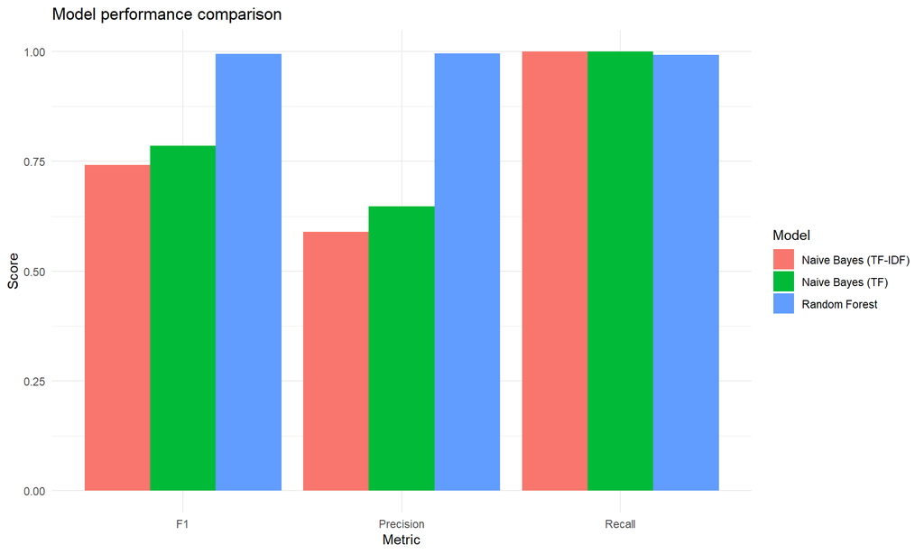

```r
# barplot for primary metrics
results_long <- results_df %>% pivot_longer(cols = Precision:F1, names_to = "Metric", values_to = "Value")

ggplot(results_long, aes(x = Metric, y = Value, fill = Model)) +
  geom_col(position = "dodge") +
  labs(title = "Model performance comparison", y = "Score") +
  theme_minimal()
```

| 11. Example predictions (inspect errors / false positives & false negatives) |
| --- |

```r
# Reconstruct test indices relative to dfm_trimmed
test_index <- setdiff(seq_len(nrow(dfm_trimmed)), train_index)

# Build table with original text and predictions
inspect_df <- tibble(
  id         = test_index,
  true_label = y_test,
  pred_nb    = nb_pred,
  pred_rf    = rf_pred,
  text       = emails_df$text[test_index]
)

# Add short preview for readability
inspect_df <- inspect_df %>%
  mutate(text_preview = str_replace_all(substr(text, 1, 160), "\\s+", " "))

# Filter only misclassified by Naive Bayes and label error type
errors_df <- inspect_df %>%
  filter((pred_nb == "spam" & true_label == "ham") |
         (pred_nb == "ham" & true_label == "spam")) %>%
  mutate(error_type = case_when(
      pred_nb == "spam" & true_label == "ham" ~ "False Positive (NB)",
      pred_nb == "ham" & true_label == "spam" ~ "False Negative (NB)"
  )) %>%
  slice(1:10) %>%
  select(id, true_label, pred_nb, pred_rf, error_type, text_preview) %>%
  knitr::kable(caption = "Example errors by Naive Bayes (showing first 10)")

errors_df
```

Example errors by Naive Bayes (showing first 10)

| id | true_label | pred_nb | pred_rf | error_type | text_preview |
| --- | --- | --- | --- | --- | --- |
| 1481 | ham | spam | ham | False Positive (NB) | From fork-admin@xent.com Mon Sep 2 16:22:38 2002 Return-Path: fork-admin@xent.com Delivered-To: zzzz@localhost.netnoteinc.com Received: from localhost (loca |
| 1569 | ham | spam | ham | False Positive (NB) | From felinda@frogstone.net Wed Aug 28 10:53:37 2002 Return-Path: felinda@frogstone.net Delivered-To: zzzz@localhost.netnoteinc.com Received: from localhost ( |
| 1583 | ham | spam | ham | False Positive (NB) | From skitster@hotmail.com Wed Aug 28 10:55:28 2002 Return-Path: skitster@hotmail.com Delivered-To: zzzz@localhost.netnoteinc.com Received: from localhost (lo |
| 1631 | ham | spam | ham | False Positive (NB) | From andy@r2-dvd.org Wed Aug 28 13:55:31 2002 Return-Path: andy@r2-dvd.org Delivered-To: zzzz@localhost.netnoteinc.com Received: from localhost (localhost [1 |
| 1633 | ham | spam | ham | False Positive (NB) | From ilug-admin@linux.ie Wed Aug 28 14:05:36 2002 Return-Path: ilug-admin@linux.ie Delivered-To: zzzz@localhost.netnoteinc.com Received: from localhost (loca |
| 1661 | ham | spam | ham | False Positive (NB) | From fork-admin@xent.com Wed Oct 9 10:55:52 2002 Return-Path: fork-admin@xent.com Delivered-To: zzzz@localhost.spamassassin.taint.org Received: from localho |
| 1698 | ham | spam | ham | False Positive (NB) | From fork-admin@xent.com Mon Aug 26 15:32:24 2002 Return-Path: fork-admin@xent.com Delivered-To: yyyy@localhost.netnoteinc.com Received: from localhost (loca |
| 1704 | ham | spam | ham | False Positive (NB) | From fork-admin@xent.com Mon Aug 26 16:57:05 2002 Return-Path: fork-admin@xent.com Delivered-To: yyyy@localhost.netnoteinc.com Received: from localhost (loca |
| 1720 | ham | spam | ham | False Positive (NB) | From fork-admin@xent.com Mon Aug 26 22:18:19 2002 Return-Path: fork-admin@xent.com Delivered-To: yyyy@localhost.netnoteinc.com Received: from localhost (loca |
| 1734 | ham | spam | ham | False Positive (NB) | From fork-admin@xent.com Tue Aug 27 03:46:39 2002 Return-Path: fork-admin@xent.com Delivered-To: yyyy@localhost.netnoteinc.com Received: from localhost (loca |

To inspect the raw text of a particular example, locate it via its id and print the corresponding emails_df$text entry to examine why the model erred.

| 12. Notes, limitations, and suggestions for improvements |
| --- |

- Preprocessing: We used stemming and stopword removal. Consider leaving words unstemmed or using lemmatization (via spaCy / UDPipe) for potentially better interpretability.
- Feature engineering: Consider TF-IDF weighting (we included a baseline), n-grams (bigrams/trigrams), character-level n-grams, and phrase detection.
- Class imbalance: If your dataset has class imbalance, try stratified sampling, class weights, or resampling (SMOTE).
- Model tuning: Use caret or tidymodels to perform cross-validation and hyperparameter tuning for Random Forest, SVM, or gradient boosting (xgboost).
- Computational limits: For very large corpora, consider using a more memory-efficient pipeline (sparse matrices on disk) or feature selection before model training.

| 13. Conclusions |
| --- |

Conclusions: This project implemented a full supervised document-classification pipeline for spam detection, including preprocessing, tokenization, feature construction, exploratory analysis, and model evaluation. Naive Bayes provided a strong baseline but showed limitations, achieving high recall at the cost of misclassifying many ham emails. The Random Forest model demonstrated near-perfect performance, correctly identifying almost all messages and achieving an AUC of 0.9999.

[output not shown]